# Medicago experiment

Ryan Farquharson

3 October 2018

## Introduction

Group B herbicides inhibit the production of branched chain amino acids, a pathway that exists in plants and also bacteria. The sulfonylurea class of group B herbicides are generally applied to cereal crops, but in certain soil types under certain conditions can persist in soils and affect other crops that are grown in rotation with cereals.

Legumes are included in crop rotations for multiple reasons, including the fixation of nitrogen. Nitrogen fixation is a symbiotic process, whereby compatible saprophytic rhizobia infect root hairs of legumes resulting in the formation of nodules inside which nitrogen fixation and a mutual exchange of compounds can occur. Both the host plants, and rhizobia, possess the pathway for production of branched chain amino acids, and acetolactate synthase (more correctly called acetohydroxyacid synthase) has been implicated in the formation of successful symbioses and potentially the transfer of nitrogen between symbionts.

This experiment was set up with the understanding that FEH-1 was tolerant of group B herbicides and would therefore provide a host background in which to determine whether the impact of group B herbicides on nitrogen fixation was entirely plant mediated or other mechanisms were at play.

The experiment was not designed to represent a real paddock in which residual herbicide were present in the soil. As such, the application of herbicide directly to plant shoots of 17 day old seedlings represents a single set of circumstances from which some conclusions can be drawn, and from which further experiments can be designed.

## Aims

This experiment was set up to:

1. compare the nodulation and nitrogen fixation of medicago truncatula cv Herald to a near isogenic herbicide tolerant variety in the absence and presence of chlorsulfuron - a group B herbicide; and
2. provide mechanistic insights into how group B herbicides affect nitrogen fixation.

Different stakeholders should be able to answer different questions from the results of this experiment.

Farmers and agronomists:

“Is nitrogen fixation by legumes being impacted upon when group B herbicides have been used?” “Is it just because biomass is knocked back, or is nfix being impacted more than plant growth?” “How well does this new variety, FEH-1 (Angel), grow and fix nitrogen in the presence and absence of herbicide?” “How can I tell what is happening in my paddocks? Do I have residual group B herbicides? Will my plants nodulate? If they nodulate, will they still fix nitrogen?”

Scientists: “What are the mechanisms by which group B herbicides impact on nitrogen fixation?” Plant only Root growth Root hairs Rhizobia only Saprophytic growth Symbiosis - Plant and rhizobia Signalling and nodule initiation Nodule development Mutual exchange of compounds

## Methonds in brief

Rhizobia were cultured in vitro with and without chlorsulfuron.

Plants were grown in pots containing a sand-vermiculite mix with limiting nitrogen.

Plants were inoculated or uninoculated with and without additional nitrogen.

Chlorsulfuron was applied using a spray rig.

Plants were harvested, acetylene reduction assays were performed, nodules counted and collected, biomass and nitrogen contents measured.

## The data

### Response variables

Since this experiment was set up with multiple objectives, a range of response variables were measured: Biomass of shoots, roots and nodules Nitrogen contents of shoots and roots plus nodules Pink nodule number Pink nodule mass Non-pink nodule number Non-pink nodule mass Acetylene reduction activity

From these response variables, a number of derived variables can be calculated: Total biomass and nitrogen Nodulation (nodule number or mass on a root biomass basis (pink or total)) Nodule activity (acetylene reduction activity per unit nodule mass or per nodule (pink or total)) Nitrogen concentrations Amount of nitrogen fixed

The response variables chosen for analysis will need to be chosen depending on the specific questions that need to be answered.

### Experimental factors

The experiment can be considered to be factorial with 3 factors and was blocked.

**Variety** (2 levels):  
* Herald: Medicago truncatula cv Herald; * FEH-1: Medicago truncatula cv FEH-1.

**Herbicide** application (2 levels): * Herbicide: chlorsulfuron applied to 17 day old seedlings; * NoHerbicide: no herbicide applied applied.

**Inoculation** (5 levels): * O-N: uninoculated without nitrogen; * O+N: uninoculated with nitrogen; * RRI128: rhizobia strain for medicago truncatula; * herb: RRI128 plus herbicide in the culture; * washed: RRI128 plus herbicide in the culture then washed

**Block** (5 blocks):  
The experiment was set up, arranged in the glasshouse, and analysed in blocks numbered 1 to 5. Each block contained all treatments, and all pots were randomised within each block.

### How many experimental conditions?

The experiment was set up with multiple objectives, thus subsets of the data should be analysed depending on the specific research question to be answered.

The Herbicide and Variety factors can be considered as a 2 by 2 factorial (4 combinations)

Depending on which response variable is being analysed, a subset of rhizobia treatments may be considered.  
For example, it makes no sense to include the uninoculated treatments in any analysis of nodulation or nodule activity. Subsets of the data were created accordingly.

The Block factor (5 blocks) can be considered to be uniform across all other treatments since all pots were randomised within a block. Hence block can be considered to be an additive factor.

### Raw data

```
## 'data.frame':    100 obs. of  15 variables:
##  $ Block         : Factor w/ 5 levels "1","2","3","4",..: 1 1 1 1 1 1 1 1 1 1 ...
##  $ Pot           : int  1 2 3 4 5 6 7 8 9 10 ...
##  $ Variety       : Factor w/ 2 levels "FEH-1","Herald": 2 2 1 1 2 2 1 1 2 2 ...
##  $ Inoculation   : Factor w/ 5 levels "RRI128","washed",..: 5 5 5 5 1 1 1 1 2 2 ...
##  $ Herbicide     : Factor w/ 2 levels "NoHerbicide",..: 1 2 1 2 1 2 1 2 1 2 ...
##  $ shootDM       : num  0.349 0.16 0.471 0.199 0.293 ...
##  $ rootDM        : num  0.1307 0.0745 0.0858 0.0694 0.1177 ...
##  $ bgDM          : num  0.1307 0.0745 0.0858 0.0694 0.131 ...
##  $ shootN        : num  17.99 9.18 23.92 13.08 11.36 ...
##  $ bgN           : num  5 3.18 2.6 2.76 4.22 ...
##  $ pinknods      : int  0 0 0 0 75 14 34 27 53 3 ...
##  $ nonpinknods   : int  0 0 0 0 24 11 3 24 12 11 ...
##  $ ara           : num  0 0 0 0 0.618 ...
##  $ pinknodmass   : num  0 0 0 0 0.013 ...
##  $ nonpinknodmass: num  0 0 0 0 0.00029 0.00012 0.00011 0.00083 0.00056 0.00051 ...
```

```
## 'data.frame':    60 obs. of  15 variables:
##  $ Block         : Factor w/ 5 levels "1","2","3","4",..: 1 1 1 1 1 1 1 1 1 1 ...
##  $ Pot           : int  5 6 7 8 9 10 11 12 13 14 ...
##  $ Variety       : Factor w/ 2 levels "FEH-1","Herald": 2 2 1 1 2 2 1 1 2 2 ...
##  $ Inoculation   : Factor w/ 5 levels "RRI128","washed",..: 1 1 1 1 2 2 2 2 3 3 ...
##  $ Herbicide     : Factor w/ 2 levels "NoHerbicide",..: 1 2 1 2 1 2 1 2 1 2 ...
##  $ shootDM       : num  0.293 0.11 0.213 0.146 0.327 ...
##  $ rootDM        : num  0.1177 0.0976 0.0801 0.0747 0.0943 ...
##  $ bgDM          : num  0.131 0.0985 0.0884 0.0786 0.1071 ...
##  $ shootN        : num  11.36 4.91 8.81 6.45 13.99 ...
##  $ bgN           : num  4.22 3.44 3.02 2.5 3.54 ...
##  $ pinknods      : int  75 14 34 27 53 3 37 44 99 9 ...
##  $ nonpinknods   : int  24 11 3 24 12 11 28 16 22 4 ...
##  $ ara           : num  0.618 0 0.33 0 1.505 ...
##  $ pinknodmass   : num  0.01304 0.00077 0.00819 0.00307 0.01227 ...
##  $ nonpinknodmass: num  0.00029 0.00012 0.00011 0.00083 0.00056 0.00051 0.00045 0.00077 0.00073 0.00004 ...
```

In R it is easy to do visualisation and analysis on calculations or transformations of the raw data.

For example, instead of making a new column called totalN for the sum of shootN and bgN, simply do plots and statistical modelling of shootN + bgN.

## Visualisation

Visualisation can be useful to quickly examine the data in relation to treatments, combinations of treatments, and to other data. The goal is to identify potential stories that we can explore further or find support for using statistical models.

### Did the experiment work?

Unfortunately, there was some nitrogen in the potting mixed used, but the uninoculated controls with and without nitrogen, we can tell that in this experiment plants were nitrogen limited. Looking at the relationship between plant biomass and plant nitrogen by inoculation type, you can clearly see that inoculated plants lie between the uninoculated plants with and without added nitrogen.

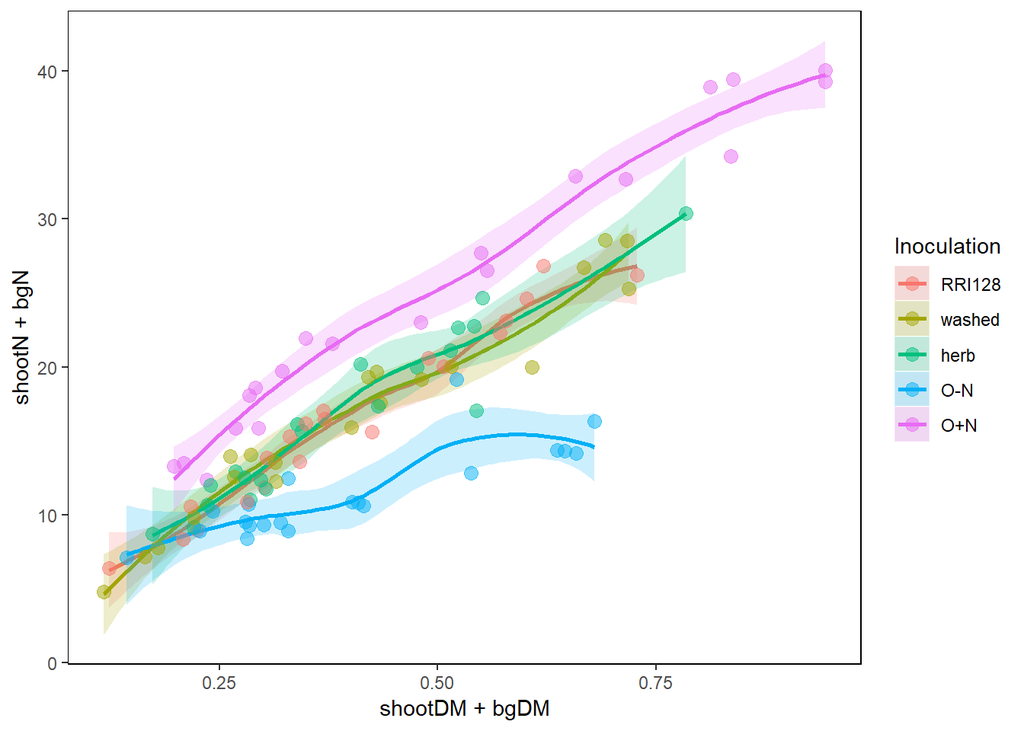

Also, none of the uninoculated plants had nodules and there was no acetylene reduction activity in any of the uninoculated plants that were tested, indicating that there was no cross contamination in the experiment (data not shown).

### Can herbicides affect nitrogen fixation?

#### Plant N

The most simple way to determine whether the amount of nitrogen fixed has been affected by chlorsulfuron is to compare the nitrogen contents for inoculated plants with and without chlorsulfuron.

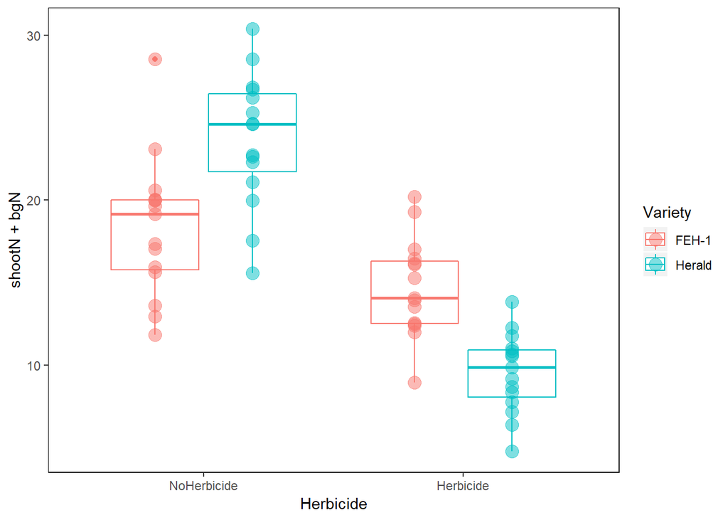

Clearly herbicide application resulted in less nitrogen in Herald plants, but probably not as severe in FEH-1 plants.

Also note that in the absence of herbicide there was more nitrogen in Herald plants than FEH-1 plants. In the presence of herbicide, the opposite was true. There’s an interaction if ever I saw one.

But is this just because biomass was lower? Let’s take a look.

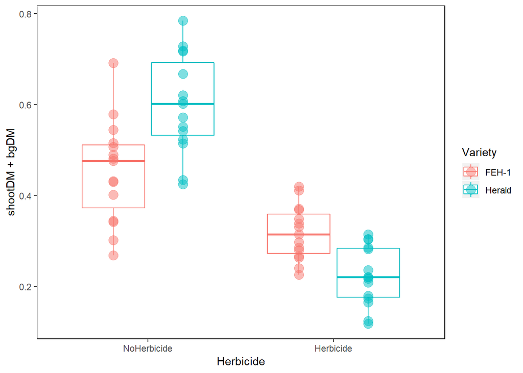

Looks familiar, right? On the surface it looks like the main story in this experiment is a biomass thing, rather than a specific effect on nitrogen fixation. But we’ll take a closer look to be sure.

#### Acetylene Reduction Assay

To zero in on nitrogen fixation itself, we have a measure on nitrogenase activity at the time of harvest - the acetylene reduction assay, whereby acetylene is reduced to ethylene (both of which we can measure in a GC with an FID) instead of nitrogen being reduced to ammonia.

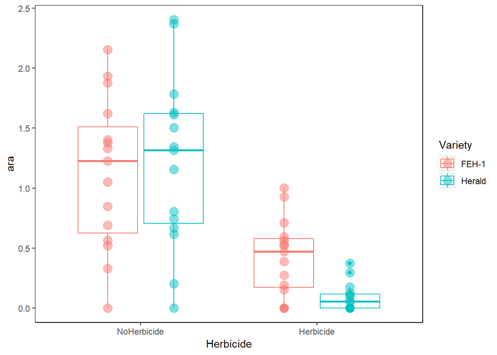

Ok, the data is noisy, but you can see that nitrogenase activity of FEH-1 and Herald plants in the absence of herbicide are on par. Both take a hit with herbicide, but FEH-1 hangs on whilst Herald really gets knocked hard.

#### Nodulation

We spent a lot of time plucking and counting nodules. Noting that herbicide was applied to shoots later than nodule initiation time, we would expect differential effects of herbicide on pink and non-pink nodules and also nodule mass. Given the timing of herbicide application, we would expect nodule mass to be affected more so than nodule number.

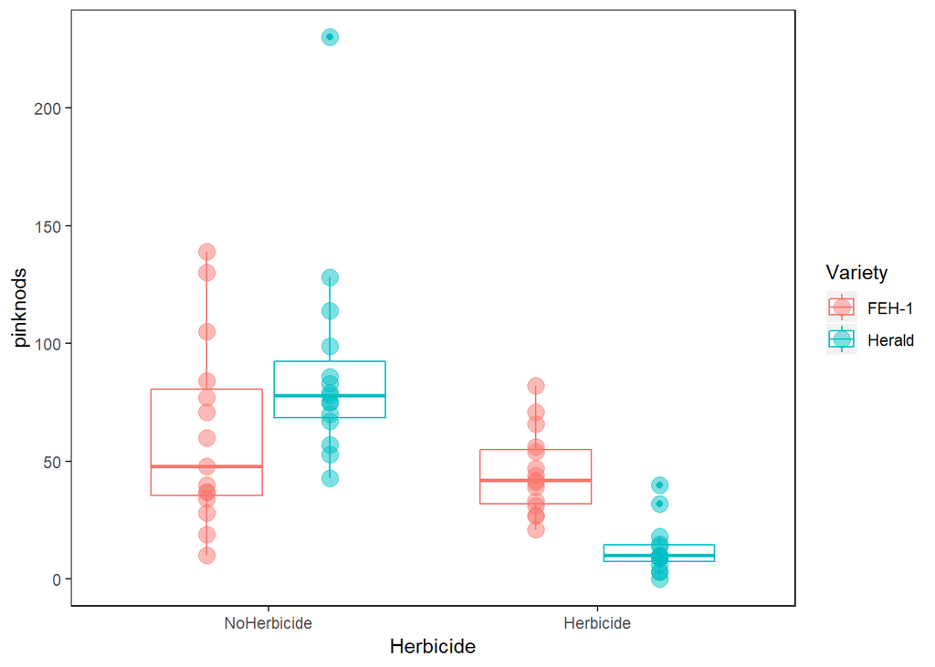

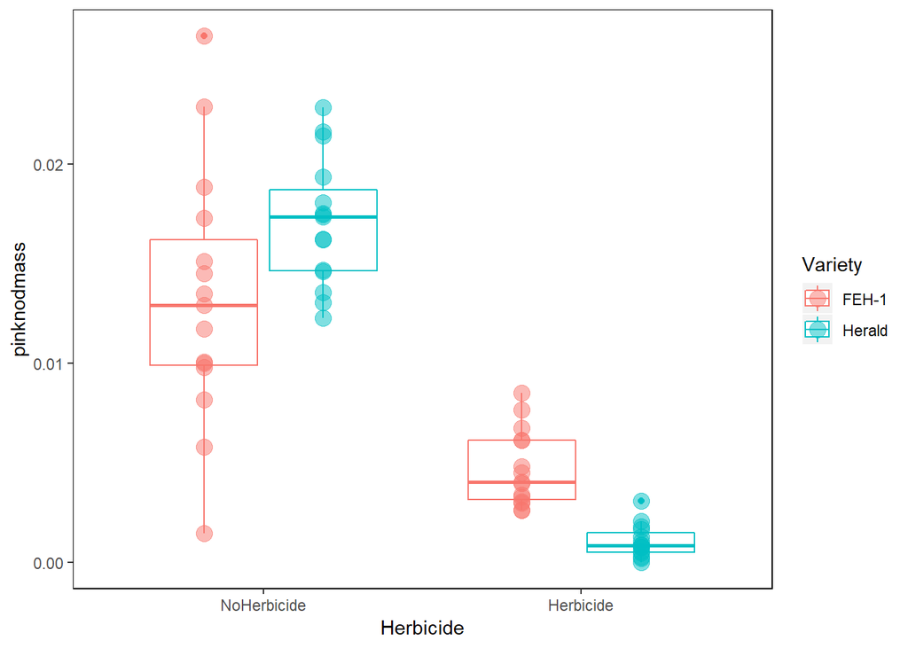

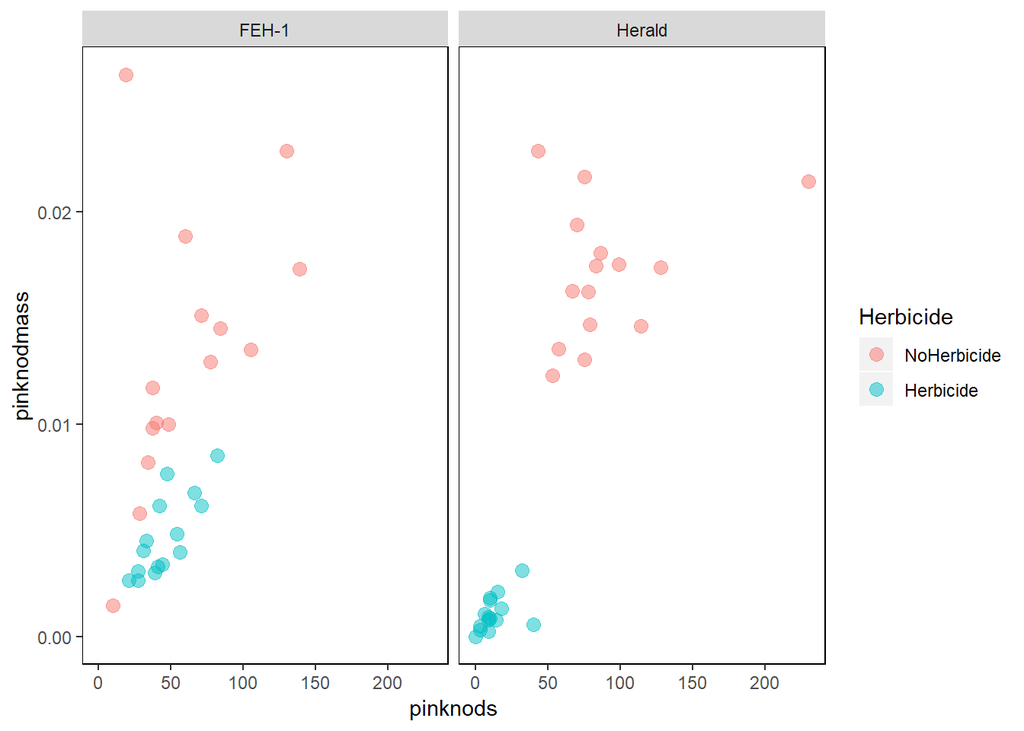

Noting that some of the nodule initiation and development would have occurred prior to herbicide application, can we see anything interesting in the relationships between ARA and nodule number or mass?

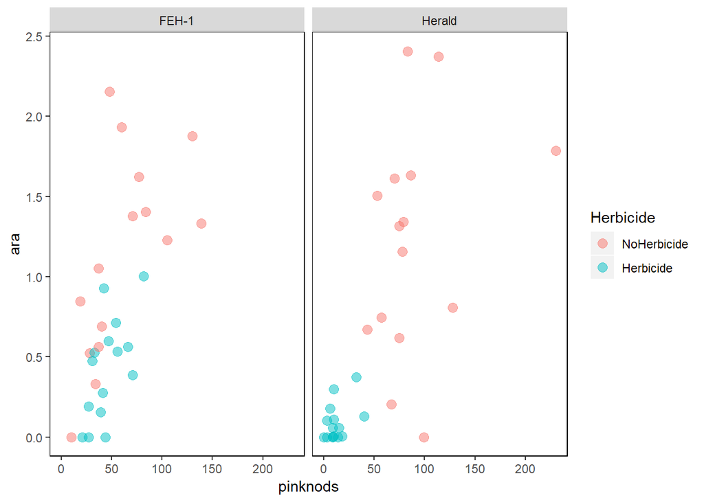

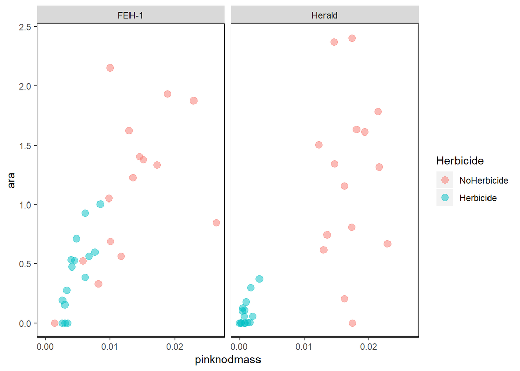

Nodule number and mass are clustering strongly with herbicide treatment for Herald, but in FEH-1 we get a bit more of a continuum.

It is also interesting that there is a good relationship between plant biomass and ARA for FEH-1, but this breaks down a bit for Herald.

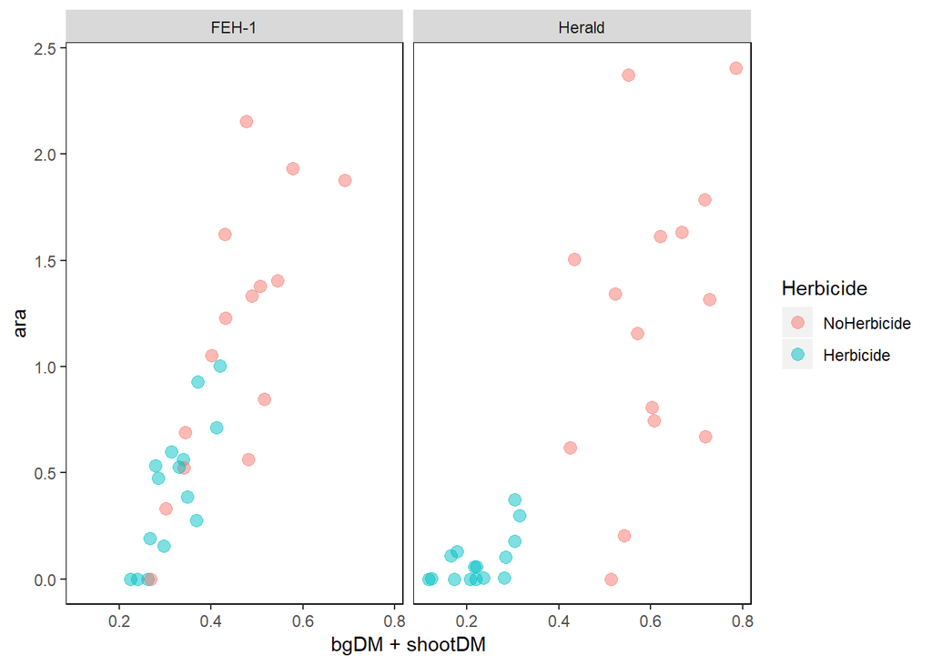

### What are the mechanisms

Is this purely a plant growth issue?

Let’s not forget the uninoculated controls…

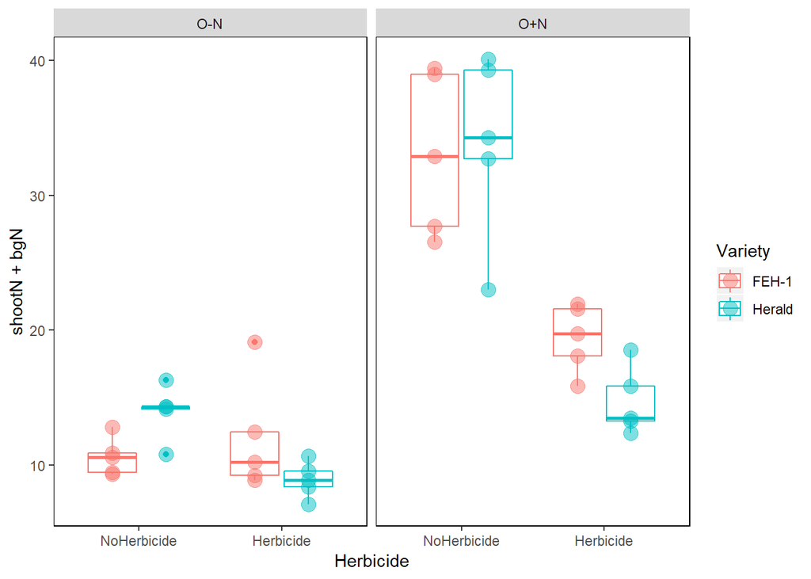

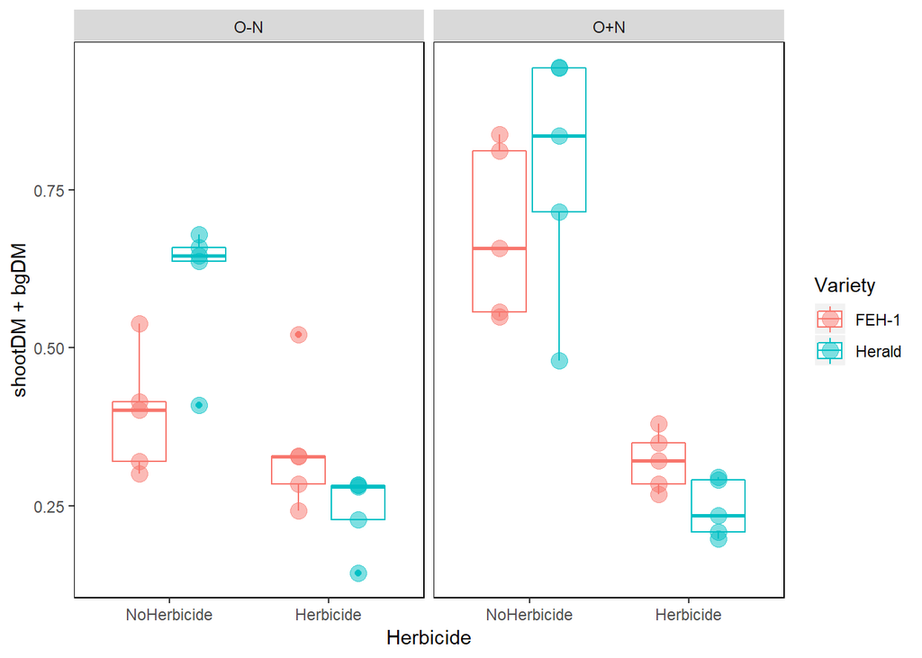

Obviously this isn’t purely a nitrogen fixation issue. Plant growth and nitrogen is being reduced by chlorsulfuron even when uninoculated plants are supplied with N. And interestingly, when looking only at uninoculated plants with excess nitrogen in the soil, we don’t see a discrepancy between FEH-1 and Herald in the absence of herbicide.

### What about the rhizobia?

Prior to inoculation, rhizobia were cultured with (herb) and without herbicide (RRI128). And to check whether herbicide was carrying over with the inoculum, we also did a rinsing procedure (washed).

There were not any obvious main effects, but it will be interesting to see whether the stats reveal any subtle interactions.

### Is FEH-1 a solution?

It looks like the answer is “Yes”. And “No”.

You’ll have noted the interactions whereby in the presence of herbicide, FEH-1 generally performed better than Herald. But in the absence of herbicide, Herald generally performed better that FEH-1.

So if group B herbicides are used in-crop, or are have been used in preceding crops and are expected to still reside in the soil, FEH-1 would be the best choice. If, group B herbicides are not an issue, stick with Herald.

## Now for some stats

We’ve looked at the data. We’ve seen some stories. Do the stats support them? Is there anything we’ve missed?

Let’s do some statistical modelling to test these ideas…

First up, let’s look at nitrogenase activity.

First we’ll try a linear model looking for interactions but putting Block as an additive fixed effect (ie Block effect is assumed to be constant across all other treatments).

```r
aralm <- lm(ara~Variety*Herbicide*Inoculation + Block, data=inoculated)
anova(aralm)
```

```
## Analysis of Variance Table
##
## Response: ara
##                               Df  Sum Sq Mean Sq F value   Pr(>F)
## Variety                        1  0.2397  0.2397  1.1231 0.295042
## Herbicide                      1 12.5437 12.5437 58.7775 1.22e-09 ***
## Inoculation                    2  0.0752  0.0376  0.1762 0.839012
## Block                          4  4.7176  1.1794  5.5265 0.001078 **
## Variety:Herbicide              1  0.6556  0.6556  3.0721 0.086612 .
## Variety:Inoculation            2  0.0417  0.0209  0.0978 0.907013
## Herbicide:Inoculation          2  0.0196  0.0098  0.0460 0.955091
## Variety:Herbicide:Inoculation  2  0.0035  0.0018  0.0083 0.991758
## Residuals                     44  9.3900  0.2134
## ---
## Signif. codes:  0 '***' 0.001 '**' 0.01 '*' 0.05 '.' 0.1 ' ' 1
```

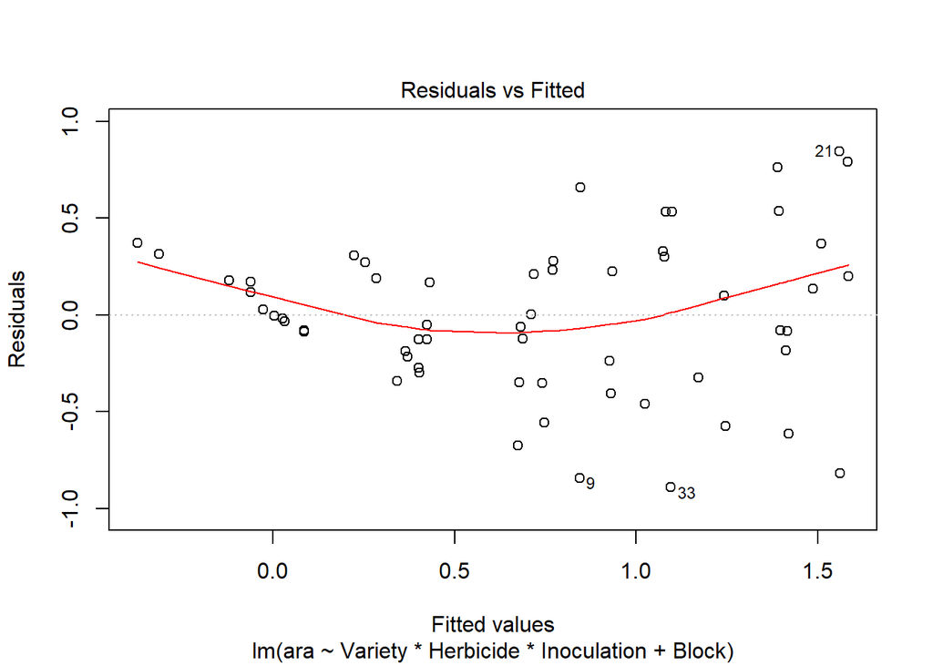

```r
plot(aralm, which = 1)
```

Note that the residuals show heteroscedacity. That is, as the fitted values increase, the residuals increase. Also note that there is curvature in the relationship between fitted values and residuals. We’ll need to do some transformations, but first let’s compare this model with an lmer whereby we put Block in the random effects part of the model.

```r
aralmer <- lmer(ara~Variety*Herbicide*Inoculation + (1|Block), data=inoculated)
anova(aralmer)
```

```
## Type III Analysis of Variance Table with Satterthwaite's method
##                                Sum Sq Mean Sq NumDF DenDF F value   Pr(>F)
## Variety                        0.2397  0.2397     1    44  1.1231  0.29504
## Herbicide                     12.5437 12.5437     1    44 58.7775 1.22e-09
## Inoculation                    0.0752  0.0376     2    44  0.1762  0.83901
## Variety:Herbicide              0.6556  0.6556     1    44  3.0721  0.08661
## Variety:Inoculation            0.0417  0.0209     2    44  0.0978  0.90701
## Herbicide:Inoculation          0.0196  0.0098     2    44  0.0460  0.95509
## Variety:Herbicide:Inoculation  0.0035  0.0018     2    44  0.0083  0.99176
##
## Variety
## Herbicide                     ***
## Inoculation
## Variety:Herbicide             .
## Variety:Inoculation
## Herbicide:Inoculation
## Variety:Herbicide:Inoculation
## ---
## Signif. codes:  0 '***' 0.001 '**' 0.01 '*' 0.05 '.' 0.1 ' ' 1
```

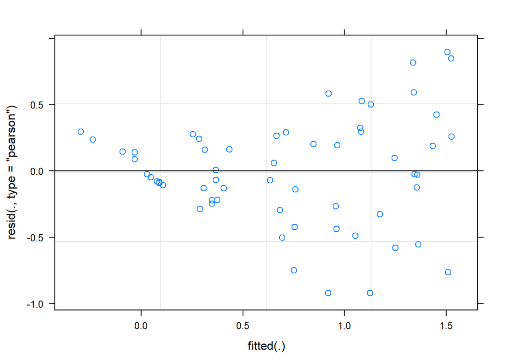

```r
plot(aralmer, which = 1)
```

We get the same thing. Unfortunately, with lmer, we don’t get the red line showing trends in fitted values vs residuals. Here, we don’t get information about the Block effect because by specifying it as part of the random effects we are saying that we don’t care about it. Personally, I find it reassuring that the block effect was quite strong. All that effort that went into randomising treatments within blocks, setting up, running and analysing the experiment in blocks, was worth it. We now have more power to look at the treatment effects.

Now for some transformations. Noting that the residuals increase as the fitted values increase, a square root transformation should be useful.

```r
sqrt_ara_lm <- lm(sqrt(ara)~Variety*Herbicide*Inoculation + Block, data=inoculated)
anova(sqrt_ara_lm)
```

```
## Analysis of Variance Table
##
## Response: sqrt(ara)
##                               Df Sum Sq Mean Sq F value    Pr(>F)
## Variety                        1 0.3759  0.3759  4.9455   0.03134 *
## Herbicide                      1 5.7890  5.7890 76.1599 3.739e-11 ***
## Inoculation                    2 0.0791  0.0395  0.5203   0.59797
## Block                          4 3.0865  0.7716 10.1515 6.547e-06 ***
## Variety:Herbicide              1 0.5332  0.5332  7.0141   0.01119 *
## Variety:Inoculation            2 0.0080  0.0040  0.0529   0.94858
## Herbicide:Inoculation          2 0.0594  0.0297  0.3906   0.67899
## Variety:Herbicide:Inoculation  2 0.0105  0.0053  0.0693   0.93314
## Residuals                     44 3.3445  0.0760
## ---
## Signif. codes:  0 '***' 0.001 '**' 0.01 '*' 0.05 '.' 0.1 ' ' 1
```

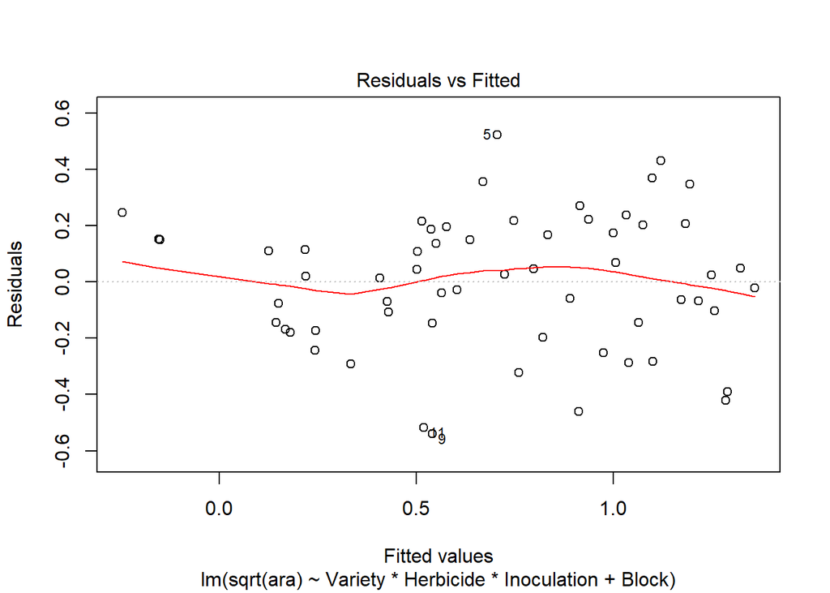

```r
plot(sqrt_ara_lm, which = 1)
```

This is an improvement. It’s not perfect - there may still be some structure in that we have few samples on the left, but I think it is acceptable, and we will be interpreting the data along with other evidence.

Again, we can repeat the analysis using lmer and put the block effect in with the random effects and we get the same thing.

```r
sqrt_ara_lmer <- lmer(sqrt(ara)~Variety*Herbicide*Inoculation + (1|Block), data=inoculated)
anova(sqrt_ara_lmer)
```

```
## Type III Analysis of Variance Table with Satterthwaite's method
##                               Sum Sq Mean Sq NumDF DenDF F value    Pr(>F)
## Variety                       0.3759  0.3759     1    44  4.9455   0.03134
## Herbicide                     5.7890  5.7890     1    44 76.1599 3.739e-11
## Inoculation                   0.0791  0.0395     2    44  0.5203   0.59797
## Variety:Herbicide             0.5332  0.5332     1    44  7.0141   0.01119
## Variety:Inoculation           0.0080  0.0040     2    44  0.0529   0.94858
## Herbicide:Inoculation         0.0594  0.0297     2    44  0.3906   0.67899
## Variety:Herbicide:Inoculation 0.0105  0.0053     2    44  0.0693   0.93314
##
## Variety                       *
## Herbicide                     ***
## Inoculation
## Variety:Herbicide             *
## Variety:Inoculation
## Herbicide:Inoculation
## Variety:Herbicide:Inoculation
## ---
## Signif. codes:  0 '***' 0.001 '**' 0.01 '*' 0.05 '.' 0.1 ' ' 1
```

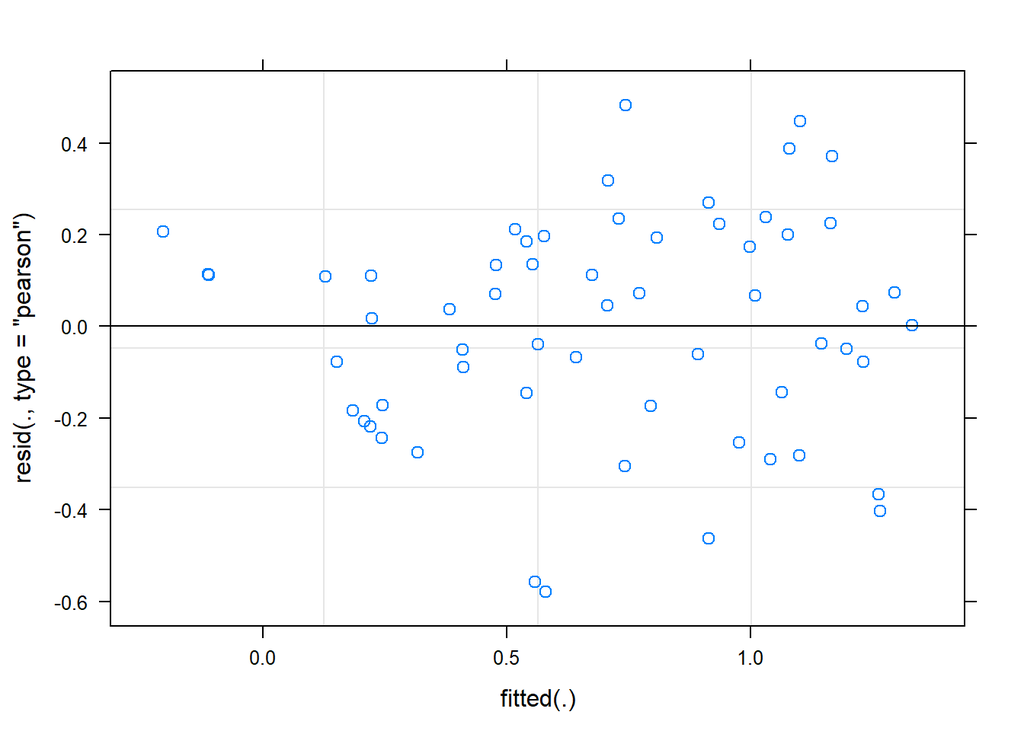

```r
#summary(sqrt_ara_lmer)
#emmeans(sqrt_ara_lmer, ~Variety*Herbicide, type = "response")
plot(sqrt_ara_lmer)
```

```r
log_ara_lm <- lm(log(ara+1)~Variety*Herbicide*Inoculation + Block, data=inoculated)
anova(log_ara_lm)
```

```
## Analysis of Variance Table
##
## Response: log(ara + 1)
##                               Df Sum Sq Mean Sq F value    Pr(>F)
## Variety                        1 0.1807  0.1807  3.2566 0.0779822 .
## Herbicide                      1 4.0681  4.0681 73.3356  6.35e-11 ***
## Inoculation                    2 0.0375  0.0187  0.3377 0.7152122
## Block                          4 1.5701  0.3925  7.0761 0.0001726 ***
## Variety:Herbicide              1 0.2939  0.2939  5.2976 0.0261477 *
## Variety:Inoculation            2 0.0027  0.0014  0.0247 0.9756303
## Herbicide:Inoculation          2 0.0152  0.0076  0.1367 0.8725764
## Variety:Herbicide:Inoculation  2 0.0034  0.0017  0.0310 0.9695353
## Residuals                     44 2.4408  0.0555
## ---
## Signif. codes:  0 '***' 0.001 '**' 0.01 '*' 0.05 '.' 0.1 ' ' 1
```

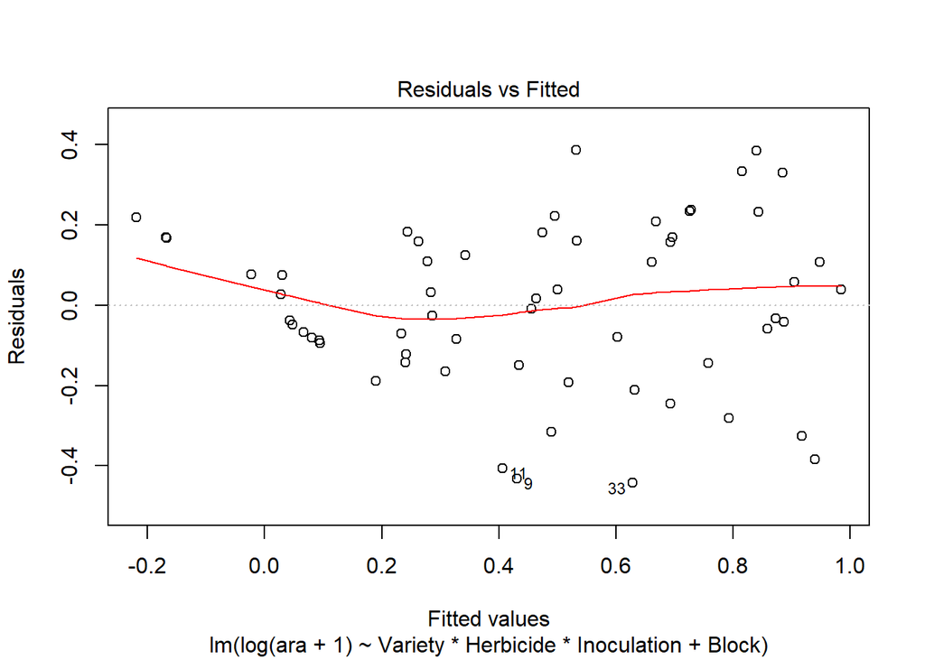

```r
#summary(log_ara_lm)
#emmeans(log_ara_lm, ~Variety*Herbicide, type = "response")
plot(log_ara_lm, which=1)
```

```r
log_ara_lmer <- lmer(log(ara+1)~Variety*Herbicide*Inoculation + (1|Block), data=inoculated)
anova(log_ara_lmer)
```

```
## Type III Analysis of Variance Table with Satterthwaite's method
##                               Sum Sq Mean Sq NumDF DenDF F value   Pr(>F)
## Variety                       0.1807  0.1807     1    44  3.2566  0.07798
## Herbicide                     4.0681  4.0681     1    44 73.3356 6.35e-11
## Inoculation                   0.0375  0.0187     2    44  0.3377  0.71521
## Variety:Herbicide             0.2939  0.2939     1    44  5.2976  0.02615
## Variety:Inoculation           0.0027  0.0014     2    44  0.0247  0.97563
## Herbicide:Inoculation         0.0152  0.0076     2    44  0.1367  0.87258
## Variety:Herbicide:Inoculation 0.0034  0.0017     2    44  0.0310  0.96954
##
## Variety                       .
## Herbicide                     ***
## Inoculation
## Variety:Herbicide             *
## Variety:Inoculation
## Herbicide:Inoculation
## Variety:Herbicide:Inoculation
## ---
## Signif. codes:  0 '***' 0.001 '**' 0.01 '*' 0.05 '.' 0.1 ' ' 1
```

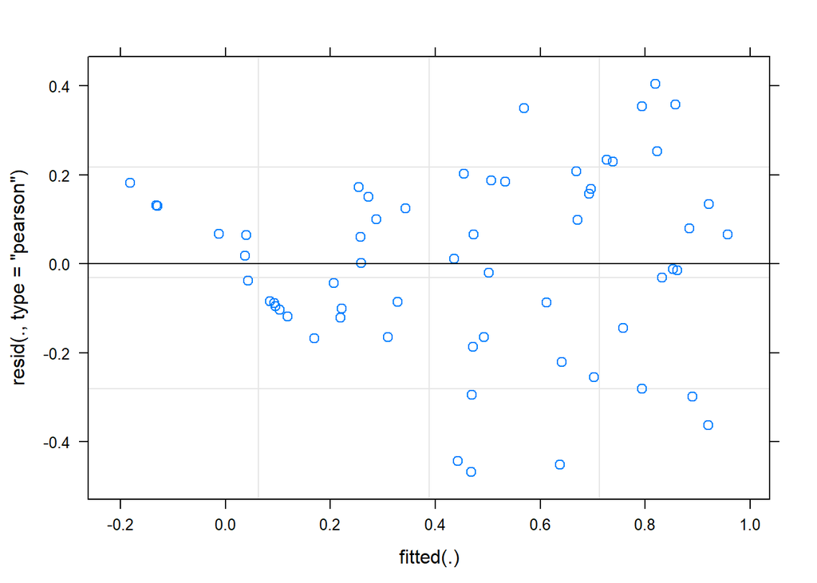

```r
#summary(log_ara_lmer)
#emmeans(log_ara_lmer, ~Variety*Herbicide, type = "response")
plot(log_ara_lmer)
```

Looking at these statistical models, they are all telling us a similar story. The rhizobia treatments make little difference, and there is an interaction between Variety and Herbicide.

So, what does the interaction mean? Well, the effect of Herbicide is dependent on Variety, or the effect of Variety is dependent on Herbicide.

We can use emmeans to give us mean values and contrasts.

```r
emmeans(log_ara_lm, ~Variety*Herbicide, type = "response")
```

```
##  Variety Herbicide   response         SE df  lower.CL upper.CL
##  FEH-1   NoHerbicide 2.033323 0.12365077 44 1.7987872 2.298439
##  Herald  NoHerbicide 2.095722 0.12744534 44 1.8539881 2.368974
##  FEH-1   Herbicide   1.389394 0.08449206 44 1.2291330 1.570551
##  Herald  Herbicide   1.082374 0.06582149 44 0.9575263 1.223500
##
## Results are averaged over the levels of: Inoculation, Block
## Confidence level used: 0.95
## Intervals are back-transformed from the log scale
```

```r
emmeans(log_ara_lmer, ~Variety*Herbicide, type = "response")
```

```
##  Variety Herbicide   response        SE   df  lower.CL upper.CL
##  FEH-1   NoHerbicide 2.033323 0.1962514 7.98 1.6274362 2.540440
##  Herald  NoHerbicide 2.095722 0.2022739 7.98 1.6773787 2.618400
##  FEH-1   Herbicide   1.389394 0.1341009 7.98 1.1120468 1.735913
##  Herald  Herbicide   1.082374 0.1044681 7.98 0.8663131 1.352321
##
## Results are averaged over the levels of: Inoculation
## Degrees-of-freedom method: satterthwaite
## Confidence level used: 0.95
## Intervals are back-transformed from the log scale
```

Using the lm or lmer, we get the same response but the SE, df and confidence intervals are different because of the way we have averaged, with and without the block effect I suspect.

The story is still the same, though. ARA of FEH-1 and Herald are the same in the absence of herbicide. But in the presence of herbicide, ARA of Herald drops more than FEH-1.

So that was a fairly in depth look at statistical modelling of ARA. There is still a lot more to look at. I am going to cut straight to what I think are the most appropriate statistical models for the variables of interest, and use the stats to support or otherwise the interpretations of the data, whilst being on the lookout for any unanticipated findings.

### Plant nitrogen

Given that our main question is whether herbicides affect the amount of nitrogen fixed by medicago, and whether using a herbicide tolerant variety can be a solution to this problem, let’s look at the amount of nitrogen in the plants. We will look at inoculated plants only (not the O-N or O+N treatments).

```r
TotalPlantN_lm <- lm(shootN + bgN ~ Variety*Herbicide*Inoculation + Block, data=inoculated)
anova(TotalPlantN_lm)
```

```
## Analysis of Variance Table
##
## Response: shootN + bgN
##                               Df  Sum Sq Mean Sq  F value    Pr(>F)
## Variety                        1    0.08    0.08   0.0121    0.9130
## Herbicide                      1 1187.10 1187.10 180.9613 < 2.2e-16 ***
## Inoculation                    2    2.02    1.01   0.1540    0.8577
## Block                          4  334.73   83.68  12.7565 5.638e-07 ***
## Variety:Herbicide              1  410.85  410.85  62.6292 5.365e-10 ***
## Variety:Inoculation            2   28.30   14.15   2.1569    0.1278
## Herbicide:Inoculation          2   22.10   11.05   1.6844    0.1973
## Variety:Herbicide:Inoculation  2    5.27    2.64   0.4019    0.6715
## Residuals                     44  288.64    6.56
## ---
## Signif. codes:  0 '***' 0.001 '**' 0.01 '*' 0.05 '.' 0.1 ' ' 1
```

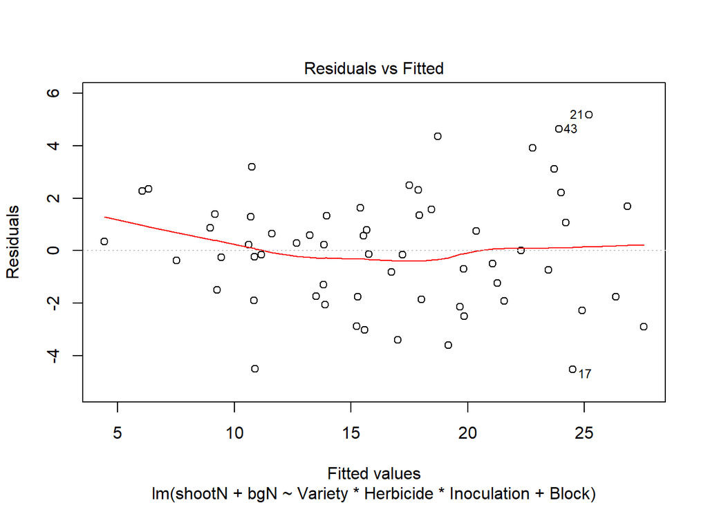

```r
plot(TotalPlantN_lm, which = 1)
```

```r
sqrtTotalPlantN_lm <- lm(sqrt(shootN + bgN) ~ Variety*Herbicide*Inoculation + Block, data=inoculated)
anova(sqrtTotalPlantN_lm)
```

```
## Analysis of Variance Table
##
## Response: sqrt(shootN + bgN)
##                               Df  Sum Sq Mean Sq  F value    Pr(>F)
## Variety                        1  0.0997  0.0997   1.0918   0.30179
## Herbicide                      1 18.6018 18.6018 203.6820 < 2.2e-16 ***
## Inoculation                    2  0.0072  0.0036   0.0396   0.96125
## Block                          4  5.3131  1.3283  14.5441 1.206e-07 ***
## Variety:Herbicide              1  6.7405  6.7405  73.8054 5.810e-11 ***
## Variety:Inoculation            2  0.5122  0.2561   2.8041   0.07142 .
## Herbicide:Inoculation          2  0.3936  0.1968   2.1551   0.12796
## Variety:Herbicide:Inoculation  2  0.0278  0.0139   0.1521   0.85935
## Residuals                     44  4.0184  0.0913
## ---
## Signif. codes:  0 '***' 0.001 '**' 0.01 '*' 0.05 '.' 0.1 ' ' 1
```

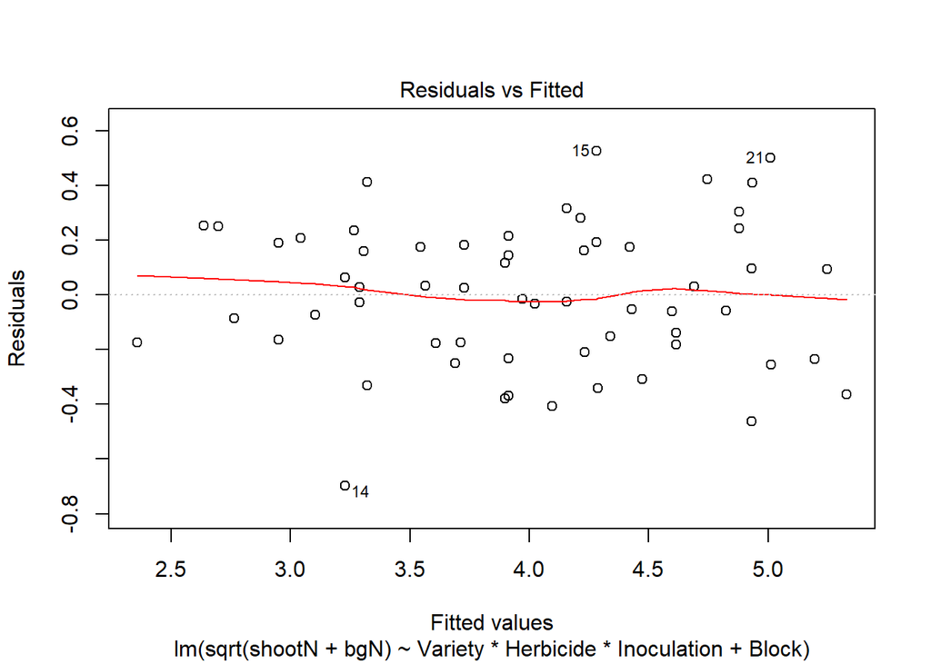

```r
plot(sqrtTotalPlantN_lm, which = 1)
```

Taking the square root improves the residuals plot a bit, but doesn’t change the story. There is a very strong Variety by Herbicide interaction, and a hint of a Variety by Inoculation interaction with the sqrt transformed data.

```r
emmeans(TotalPlantN_lm, ~ Variety*Herbicide)
```

```
##  Variety Herbicide      emmean        SE df  lower.CL upper.CL
##  FEH-1   NoHerbicide 18.363372 0.6613101 44 17.030589 19.69615
##  Herald  NoHerbicide 23.669563 0.6613101 44 22.336780 25.00235
##  FEH-1   Herbicide   14.700820 0.6613101 44 13.368037 16.03360
##  Herald  Herbicide    9.539981 0.6613101 44  8.207198 10.87276
##
## Results are averaged over the levels of: Inoculation, Block
## Confidence level used: 0.95
```

This is a very clear example of an interaction. In the absence of herbicide, Herald plants contained more nitrogen than FEH-1 plants. In the presence of herbicide, nitrogen contents declined more for Herald plants than FEH-1 plants so that FEH-1 plants had more nitrogen the Herald plants. We already knew that from the visualisation. The stats back it up.

Just to satisfy myself, I will repeat using lmer and put the Block effect into the noise.

```r
sqrtTotalPlantN_lmer <- lmer(sqrt(shootN + bgN) ~ Variety*Herbicide*Inoculation + (1|Block), data=inoculated)
anova(sqrtTotalPlantN_lmer)
```

```
## Type III Analysis of Variance Table with Satterthwaite's method
##                                Sum Sq Mean Sq NumDF DenDF  F value
## Variety                        0.0997  0.0997     1    44   1.0918
## Herbicide                     18.6018 18.6018     1    44 203.6820
## Inoculation                    0.0072  0.0036     2    44   0.0396
## Variety:Herbicide              6.7405  6.7405     1    44  73.8054
## Variety:Inoculation            0.5122  0.2561     2    44   2.8041
## Herbicide:Inoculation          0.3936  0.1968     2    44   2.1551
## Variety:Herbicide:Inoculation  0.0278  0.0139     2    44   0.1521
##                                  Pr(>F)
## Variety                         0.30179
## Herbicide                     < 2.2e-16 ***
## Inoculation                     0.96125
## Variety:Herbicide              5.81e-11 ***
## Variety:Inoculation             0.07142 .
## Herbicide:Inoculation           0.12796
## Variety:Herbicide:Inoculation   0.85935
## ---
## Signif. codes:  0 '***' 0.001 '**' 0.01 '*' 0.05 '.' 0.1 ' ' 1
```

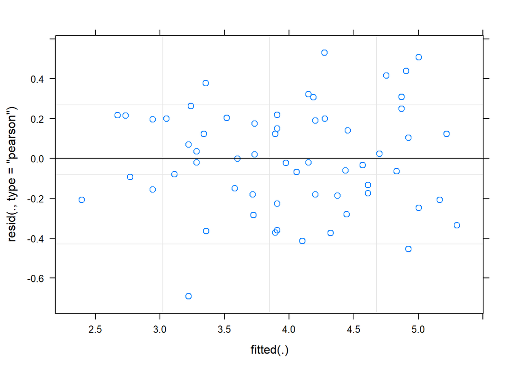

```r
plot(sqrtTotalPlantN_lmer)
```

```r
emmeans(sqrtTotalPlantN_lmer, ~ Variety*Herbicide, type="response")
```

```
##  Variety Herbicide   response       SE  df  lower.CL upper.CL
##  FEH-1   NoHerbicide 18.13945 1.391978 5.8 14.867036 21.73710
##  Herald  NoHerbicide 23.50174 1.584421 5.8 19.754437 27.57430
##  FEH-1   Herbicide   14.56020 1.247108 5.8 11.645291 17.80035
##  Herald  Herbicide    9.38752 1.001373 5.8  7.079019 12.02126
##
## Results are averaged over the levels of: Inoculation
## Degrees-of-freedom method: satterthwaite
## Confidence level used: 0.95
## Intervals are back-transformed from the sqrt scale
```

```r
TotalPlantN_lmer <- lmer(shootN + bgN ~ Variety*Herbicide*Inoculation + (1|Block), data=inoculated)
anova(TotalPlantN_lmer)
```

```
## Type III Analysis of Variance Table with Satterthwaite's method
##                                Sum Sq Mean Sq NumDF DenDF  F value
## Variety                          0.08    0.08     1    44   0.0121
## Herbicide                     1187.10 1187.10     1    44 180.9613
## Inoculation                      2.02    1.01     2    44   0.1540
## Variety:Herbicide              410.85  410.85     1    44  62.6292
## Variety:Inoculation             28.30   14.15     2    44   2.1569
## Herbicide:Inoculation           22.10   11.05     2    44   1.6844
## Variety:Herbicide:Inoculation    5.27    2.64     2    44   0.4019
##                                  Pr(>F)
## Variety                          0.9130
## Herbicide                     < 2.2e-16 ***
## Inoculation                      0.8577
## Variety:Herbicide             5.365e-10 ***
## Variety:Inoculation              0.1278
## Herbicide:Inoculation            0.1973
## Variety:Herbicide:Inoculation    0.6715
## ---
## Signif. codes:  0 '***' 0.001 '**' 0.01 '*' 0.05 '.' 0.1 ' ' 1
```

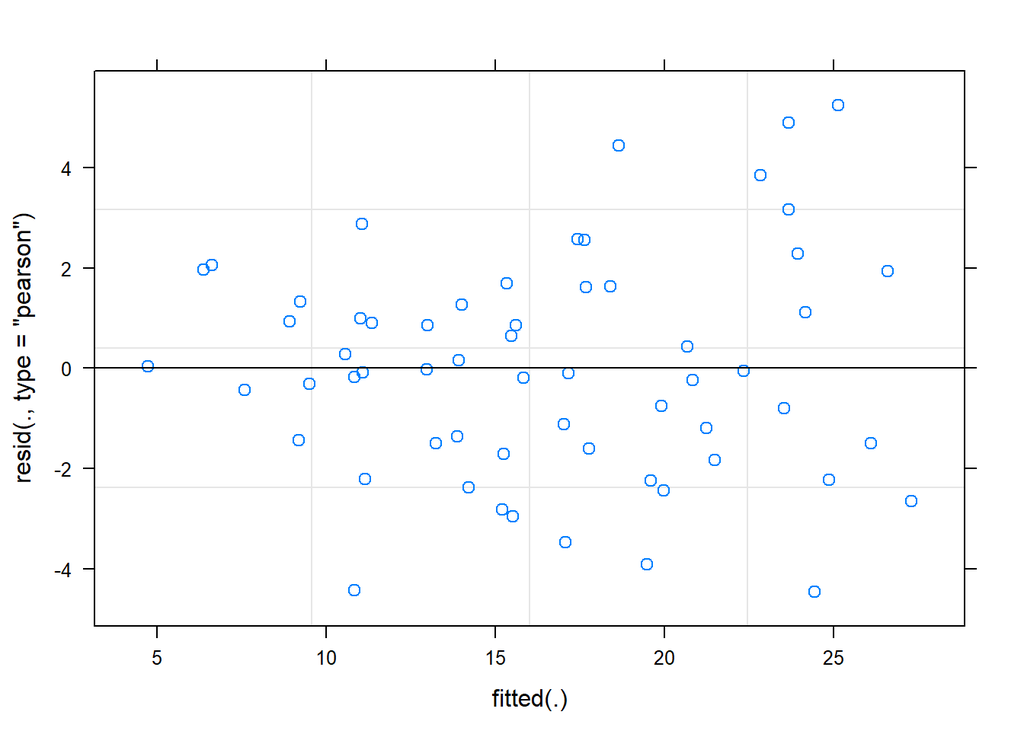

```r
plot(TotalPlantN_lmer)
```

```r
emmeans(TotalPlantN_lmer, ~ Variety*Herbicide)
```

```
##  Variety Herbicide      emmean       SE   df  lower.CL upper.CL
##  FEH-1   NoHerbicide 18.363372 1.312517 6.07 15.160978 21.56577
##  Herald  NoHerbicide 23.669563 1.312517 6.07 20.467169 26.87196
##  FEH-1   Herbicide   14.700820 1.312517 6.07 11.498427 17.90321
##  Herald  Herbicide    9.539981 1.312517 6.07  6.337587 12.74237
##
## Results are averaged over the levels of: Inoculation
## Degrees-of-freedom method: satterthwaite
## Confidence level used: 0.95
```

Different confidence intervals, but same story really.

What if we look at shoots and below ground separately?

First the shoots…

```r
shootN_lm <- lm(shootN ~ Variety*Herbicide*Inoculation + Block, data=inoculated)
anova(shootN_lm)
```

```
## Analysis of Variance Table
##
## Response: shootN
##                               Df Sum Sq Mean Sq  F value    Pr(>F)
## Variety                        1  10.08   10.08   2.4167    0.1272
## Herbicide                      1 859.50  859.50 206.1060 < 2.2e-16 ***
## Inoculation                    2   4.46    2.23   0.5348    0.5896
## Block                          4 126.52   31.63   7.5850  9.73e-05 ***
## Variety:Herbicide              1 358.14  358.14  85.8806  6.62e-12 ***
## Variety:Inoculation            2  15.71    7.86   1.8840    0.1640
## Herbicide:Inoculation          2   9.65    4.82   1.1565    0.3240
## Variety:Herbicide:Inoculation  2   6.00    3.00   0.7193    0.4927
## Residuals                     44 183.49    4.17
## ---
## Signif. codes:  0 '***' 0.001 '**' 0.01 '*' 0.05 '.' 0.1 ' ' 1
```

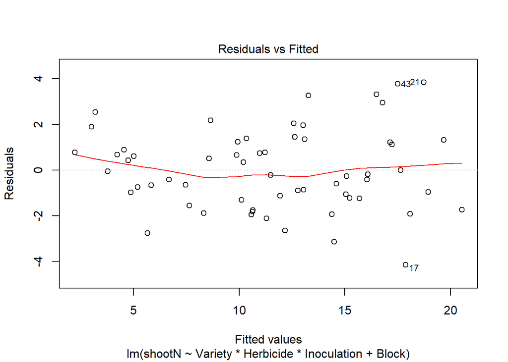

```r
plot(shootN_lm, which =1)
```

```r
emmeans(shootN_lm, ~ Variety*Herbicide)
```

```
##  Variety Herbicide      emmean        SE df  lower.CL  upper.CL
##  FEH-1   NoHerbicide 13.332122 0.5272688 44 12.269481 14.394762
##  Herald  NoHerbicide 17.398730 0.5272688 44 16.336089 18.461370
##  FEH-1   Herbicide   10.648737 0.5272688 44  9.586097 11.711377
##  Herald  Herbicide    4.942758 0.5272688 44  3.880118  6.005399
##
## Results are averaged over the levels of: Inoculation, Block
## Confidence level used: 0.95
```

The shoots are responding with that classic Variety by Herbicide interaction.

Now for the roots+nodules…

```r
bgN_lm <- lm(bgN ~ Variety*Herbicide*Inoculation + Block, data=inoculated)
anova(bgN_lm)
```

```
## Analysis of Variance Table
##
## Response: bgN
##                               Df Sum Sq Mean Sq F value    Pr(>F)
## Variety                        1 11.945 11.9446 19.2030 7.189e-05 ***
## Herbicide                      1 26.390 26.3896 42.4258 5.926e-08 ***
## Inoculation                    2  1.119  0.5597  0.8998   0.41402
## Block                          4 58.343 14.5858 23.4491 1.978e-10 ***
## Variety:Herbicide              1  1.808  1.8084  2.9074   0.09523 .
## Variety:Inoculation            2  1.852  0.9259  1.4885   0.23685
## Herbicide:Inoculation          2  2.874  1.4369  2.3101   0.11117
## Variety:Herbicide:Inoculation  2  0.062  0.0312  0.0502   0.95107
## Residuals                     44 27.369  0.6220
## ---
## Signif. codes:  0 '***' 0.001 '**' 0.01 '*' 0.05 '.' 0.1 ' ' 1
```

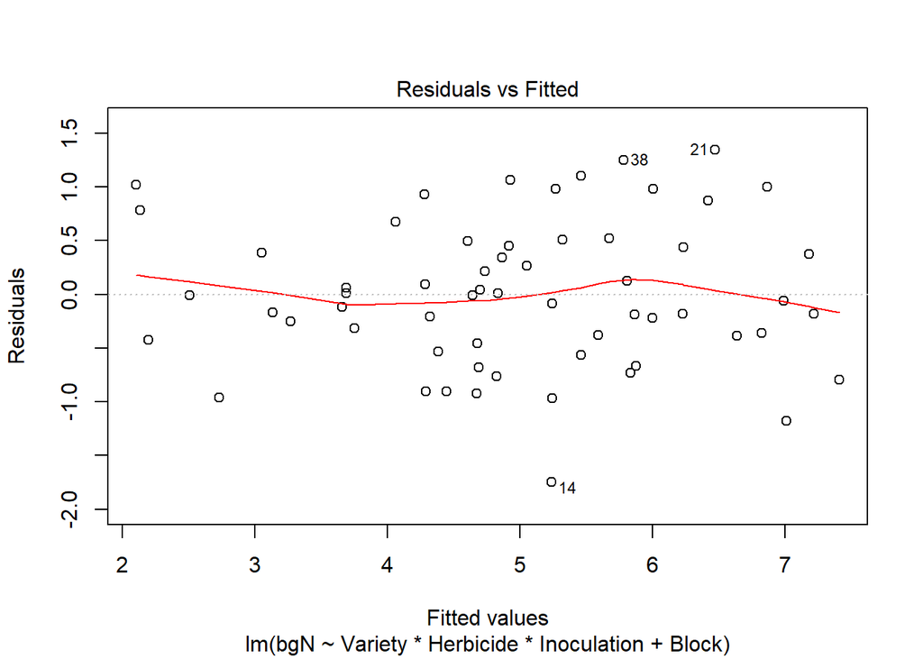

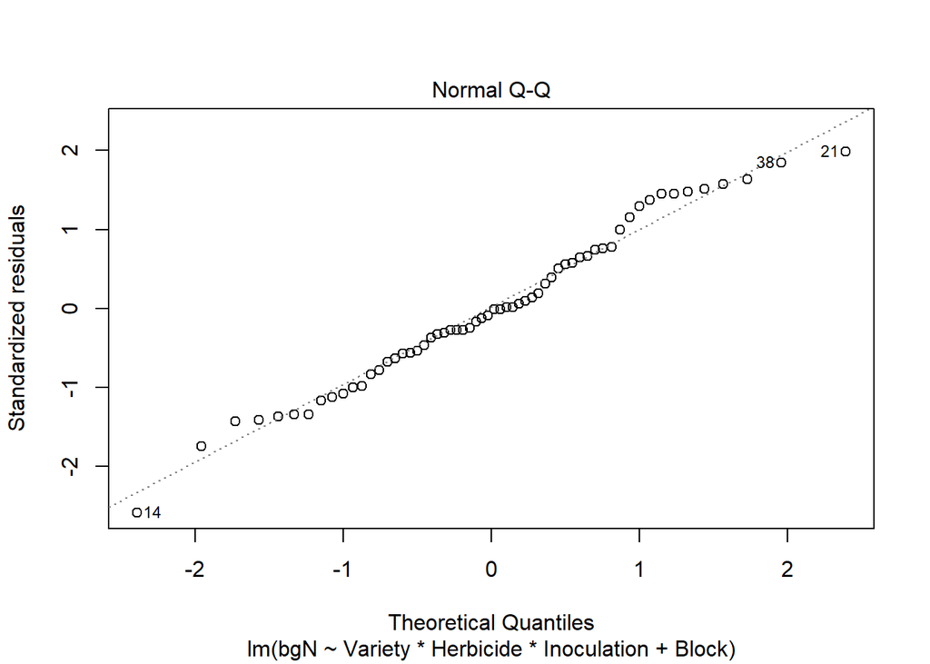

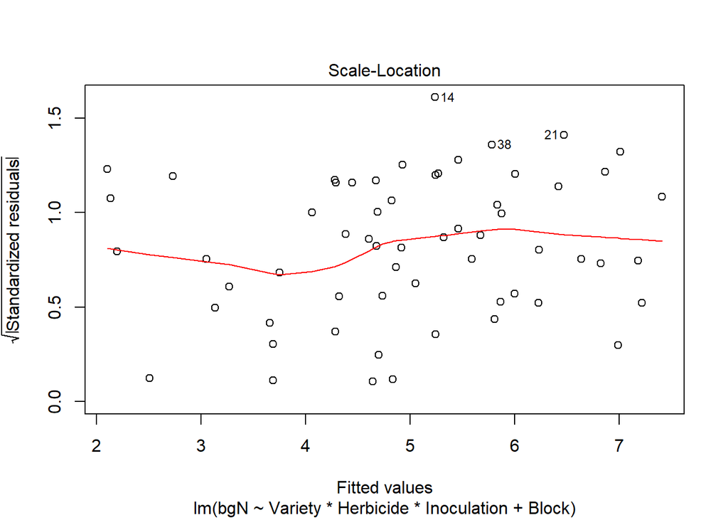

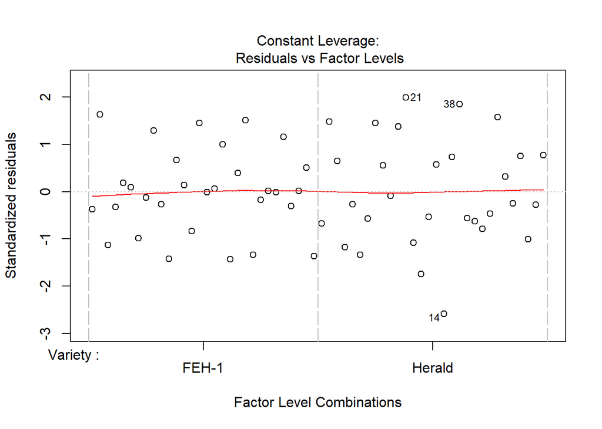

```r
plot(bgN_lm)
```

```r
emmeans(bgN_lm, ~ Variety*Herbicide)
```

```
##  Variety Herbicide     emmean        SE df lower.CL upper.CL
##  FEH-1   NoHerbicide 5.031250 0.2036366 44 4.620847 5.441653
##  Herald  NoHerbicide 6.270833 0.2036366 44 5.860431 6.681236
##  FEH-1   Herbicide   4.052083 0.2036366 44 3.641681 4.462486
##  Herald  Herbicide   4.597222 0.2036366 44 4.186820 5.007625
##
## Results are averaged over the levels of: Inoculation, Block
## Confidence level used: 0.95
```

```r
emmeans(bgN_lm, pairwise ~ Herbicide)
```

```
## $emmeans
##  Herbicide     emmean        SE df lower.CL upper.CL
##  NoHerbicide 5.651042 0.1439928 44 5.360843 5.941240
##  Herbicide   4.324653 0.1439928 44 4.034454 4.614851
##
## Results are averaged over the levels of: Variety, Inoculation, Block
## Confidence level used: 0.95
##
## $contrasts
##  contrast                estimate        SE df t.ratio p.value
##  NoHerbicide - Herbicide 1.326389 0.2036366 44   6.514  <.0001
##
## Results are averaged over the levels of: Variety, Inoculation, Block
```

```r
emmeans(bgN_lm, pairwise ~ Variety)
```

```
## $emmeans
##  Variety   emmean        SE df lower.CL upper.CL
##  FEH-1   4.541667 0.1439928 44 4.251468 4.831865
##  Herald  5.434028 0.1439928 44 5.143829 5.724226
##
## Results are averaged over the levels of: Herbicide, Inoculation, Block
## Confidence level used: 0.95
##
## $contrasts
##  contrast         estimate        SE df t.ratio p.value
##  FEH-1 - Herald -0.8923611 0.2036366 44  -4.382  0.0001
##
## Results are averaged over the levels of: Herbicide, Inoculation, Block
```

A hint of an interaction, but we can only be confident about the main effects of Variety and Herbicide, where NoHerbicide was greater than Herbicide, and Herald was greater than FEH-1.

This is interesting. In our visualisation we only looked at whole plant nitrogen and biomass. But the statistical modelling suggests that the shoots and roots+nodules are responding differently. This is poignant given that the herbicide was applied to the shoots, and nodulation occurs in the roots. This is useful information that could inform the design of a subsequent experiment.

Time permitting it would be good to be able to plot shoots and bg on the same plot, above and below the x axis.

### Plant biomass

#### Shoots

```r
shootDM_lm <- lm(shootDM ~ Variety*Herbicide*Inoculation + Block, data=inoculated)
anova(shootDM_lm)
```

```
## Analysis of Variance Table
##
## Response: shootDM
##                               Df  Sum Sq Mean Sq  F value    Pr(>F)
## Variety                        1 0.00149 0.00149   0.6604   0.42079
## Herbicide                      1 0.64029 0.64029 284.1743 < 2.2e-16 ***
## Inoculation                    2 0.00503 0.00251   1.1152   0.33693
## Block                          4 0.07067 0.01767   7.8417 7.324e-05 ***
## Variety:Herbicide              1 0.16064 0.16064  71.2960 9.387e-11 ***
## Variety:Inoculation            2 0.00334 0.00167   0.7418   0.48210
## Herbicide:Inoculation          2 0.01251 0.00625   2.7757   0.07324 .
## Variety:Herbicide:Inoculation  2 0.00014 0.00007   0.0310   0.96951
## Residuals                     44 0.09914 0.00225
## ---
## Signif. codes:  0 '***' 0.001 '**' 0.01 '*' 0.05 '.' 0.1 ' ' 1
```

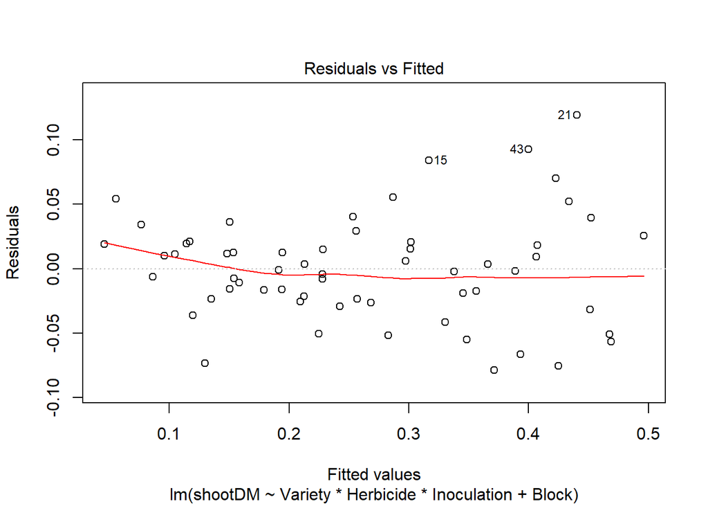

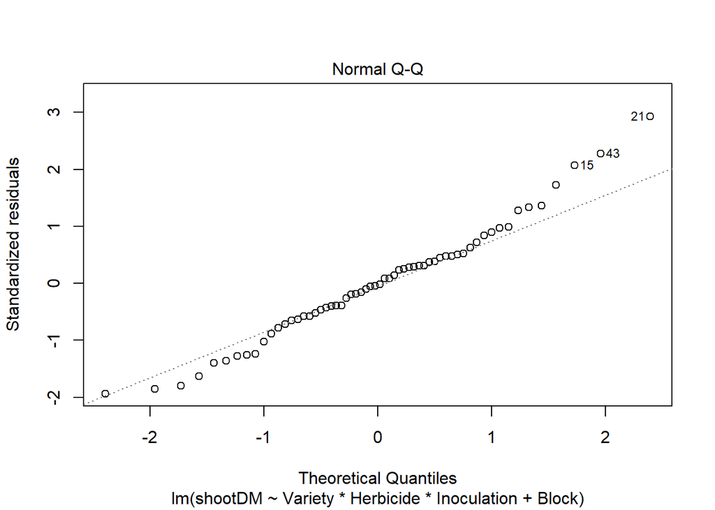

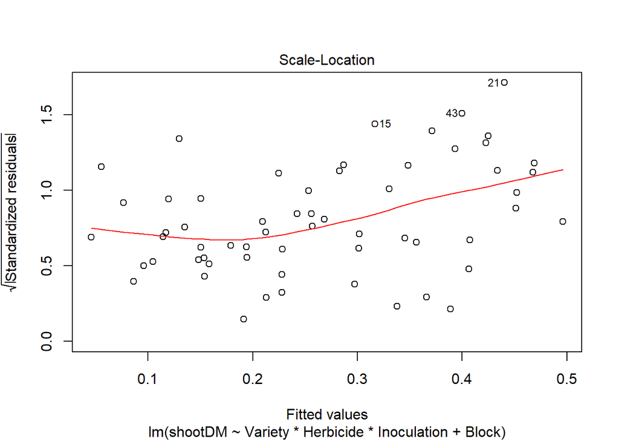

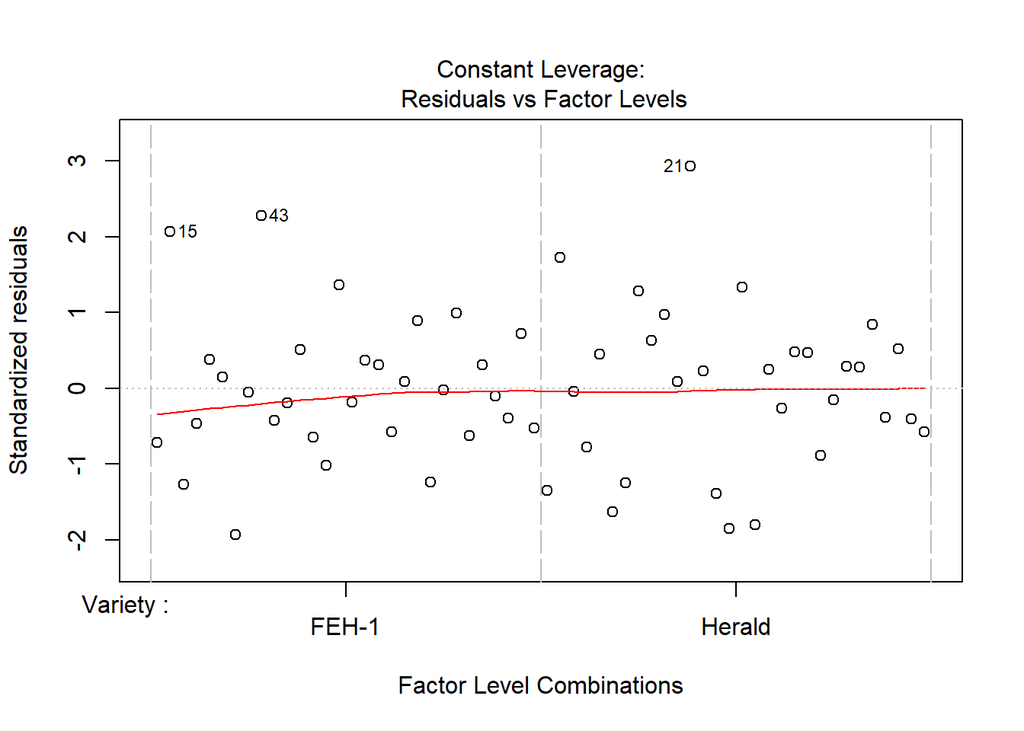

```r
plot(shootDM_lm)
```

```r
emmeans(shootDM_lm, ~ Variety*Herbicide)
```

```
##  Variety Herbicide      emmean         SE df   lower.CL  upper.CL
##  FEH-1   NoHerbicide 0.3110667 0.01225609 44 0.28636614 0.3357672
##  Herald  NoHerbicide 0.4245133 0.01225609 44 0.39981281 0.4492139
##  FEH-1   Herbicide   0.2079467 0.01225609 44 0.18324614 0.2326472
##  Herald  Herbicide   0.1144200 0.01225609 44 0.08971947 0.1391205
##
## Results are averaged over the levels of: Inoculation, Block
## Confidence level used: 0.95
```

```r
sqrtshootDM_lm <- lm(sqrt(shootDM) ~ Variety*Herbicide*Inoculation + Block, data=inoculated)
anova(sqrtshootDM_lm)
```

```
## Analysis of Variance Table
##
## Response: sqrt(shootDM)
##                               Df  Sum Sq Mean Sq  F value    Pr(>F)
## Variety                        1 0.00223 0.00223   1.2237   0.27466
## Herbicide                      1 0.64537 0.64537 354.3969 < 2.2e-16 ***
## Inoculation                    2 0.00254 0.00127   0.6969   0.50356
## Block                          4 0.06689 0.01672   9.1837 1.748e-05 ***
## Variety:Herbicide              1 0.17177 0.17177  94.3266 1.632e-12 ***
## Variety:Inoculation            2 0.00475 0.00238   1.3044   0.28162
## Herbicide:Inoculation          2 0.01217 0.00608   3.3414   0.04457 *
## Variety:Herbicide:Inoculation  2 0.00005 0.00002   0.0132   0.98686
## Residuals                     44 0.08013 0.00182
## ---
## Signif. codes:  0 '***' 0.001 '**' 0.01 '*' 0.05 '.' 0.1 ' ' 1
```